# Labor_supply

```python
# Load needed libraries

%matplotlib inline

import numpy as np
import pandas as pd
import matplotlib.pyplot as plt
```

```python
OECD = pd.read_csv('data/OECD_Productivity.csv')
OECD.head()
```

|  | LOCATION | Country | SUBJECT | Subject | MEASURE | Measure | TIME | Time | Unit Code | Unit | PowerCode Code | PowerCode | Reference Period Code | Reference Period | Value | Flag Codes | Flags |
| --- | --- | --- | --- | --- | --- | --- | --- | --- | --- | --- | --- | --- | --- | --- | --- | --- | --- |
| 0 | AUS | Australia | T_GDP | Gross Domestic Product (GDP); millions | C | National currency, current prices | 1970 | 1970 | NATCUR | National currency | 6 | Millions | NaN | NaN | 40304.0 | NaN | NaN |
| 1 | AUS | Australia | T_GDP | Gross Domestic Product (GDP); millions | C | National currency, current prices | 1971 | 1971 | NATCUR | National currency | 6 | Millions | NaN | NaN | 44473.0 | NaN | NaN |
| 2 | AUS | Australia | T_GDP | Gross Domestic Product (GDP); millions | C | National currency, current prices | 1972 | 1972 | NATCUR | National currency | 6 | Millions | NaN | NaN | 49735.0 | NaN | NaN |
| 3 | AUS | Australia | T_GDP | Gross Domestic Product (GDP); millions | C | National currency, current prices | 1973 | 1973 | NATCUR | National currency | 6 | Millions | NaN | NaN | 60257.0 | NaN | NaN |
| 4 | AUS | Australia | T_GDP | Gross Domestic Product (GDP); millions | C | National currency, current prices | 1974 | 1974 | NATCUR | National currency | 6 | Millions | NaN | NaN | 71141.0 | NaN | NaN |

```python
df = OECD.copy()

countries = OECD['Country'].unique()
locs = OECD['LOCATION'].unique()

df = df.loc[df['Subject'].isin(('GDP per hour worked', 'Average hours worked per person employed'))]

df = df.loc[df['Measure'].isin(('USD, constant prices, 2010 PPPs', 'Persons/Hours'))]

df = df[['LOCATION', 'Subject', 'Time', 'Value']]

# Set MultiIndex; can choose ordering
df.set_index(['Subject', 'LOCATION', 'Time'], inplace=True)

# Create nested columns
df = df.unstack(0)

# Remove one unnecessary level of naming
df = df['Value']

df.columns = ['h', 'y_h']

df['cntr'] = df.index.get_level_values(0)

# Show prepared dataset
df.head()
```

| LOCATION | Time | h | y_h | cntr |
| --- | --- | --- | --- | --- |
| AUS | 1970 | 1864.935951 | 26.798955 | AUS |
|  | 1971 | 1847.040484 | 27.468817 | AUS |
|  | 1972 | 1827.516925 | 28.073389 | AUS |
|  | 1973 | 1814.705069 | 28.651563 | AUS |
|  | 1974 | 1831.279122 | 28.195604 | AUS |

```python
x = df['h']
y = df['y_h']
```

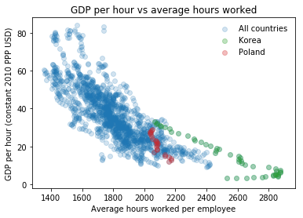

```python
plt.scatter(x, y, alpha=0.2, label='All countries')
plt.scatter(x['KOR'], y['KOR'], color='C2', alpha=0.3, label='Korea')
plt.scatter(x['POL'], y['POL'], color='C3', alpha=0.3, label='Poland')

plt.legend(frameon=False)

plt.title('GDP per hour vs average hours worked')
plt.xlabel('Average hours worked per employee')
plt.ylabel('GDP per hour (constant 2010 PPP USD)')

plt.show()
```

[figure not shown]

```python
for loc in locs[:9]:
    plt.scatter(np.log(x[loc]), np.log(y[loc]), alpha=0.2, label=loc)

plt.legend(frameon=False, ncol=2)

plt.title('GDP per hour vs average hours worked')
plt.ylabel('Average hours worked per employee')
plt.xlabel('GDP per hour (constant 2010 PPP USD)')

plt.show()
```

Utility maximization problem \begin{align*} \max_{c,\,h}\quad & U=\frac{c^{1-\sigma}}{1-\sigma}-\phi\frac{h^{1+\kappa}}{1+\kappa}\\ \text{subject to}\quad & y=Ah^{1-\alpha}\\ & c=y \end{align*}

Lagrangian \begin{align*} \mathcal{L}&=\frac{c^{1-\sigma}}{1-\sigma}-\phi\frac{h^{1+\kappa}}{1+\kappa}+\lambda\left[Ah^{1-\alpha}-c\right] \end{align*}

FOCs \begin{eqnarray*} c & : & c^{-\sigma}-\lambda=0\\ h & : & -\phi h^{\kappa}+\lambda\left(1-\alpha\right)Ah^{-\alpha}=0 \end{eqnarray*}

Optimality condition \begin{align*} \left(1-\alpha\right)Ah^{-\alpha}c^{-\sigma}=\phi h^{\kappa} \end{align*} \begin{align*} c&=\left[\frac{\phi}{\left(1-\alpha\right)A}h^{\alpha+\kappa}\right]^{-\frac{1}{\sigma}}&=\left[\frac{\left(1-\alpha\right)A}{\phi}\right]^{\frac{1}{\sigma}}h^{-\frac{\alpha+\kappa}{\sigma}} \end{align*} Plug into budget constraint and solve for optimal $h$ \begin{align*} \left[\frac{\left(1-\alpha\right)A}{\phi}\right]^{\frac{1}{\sigma}}h^{-\frac{\alpha+\kappa}{\sigma}}&=Ah^{1-\alpha} \end{align*} \begin{align*} h^{-\frac{\alpha+\kappa+\sigma\left(1-\alpha\right)}{\sigma}}&=A^{\frac{\sigma-1}{\sigma}}\left(\frac{\phi}{1-\alpha}\right)^{\frac{1}{\sigma}} \end{align*} \begin{align*} h&=A^{\frac{1-\sigma}{\alpha+\kappa+\sigma\left(1-\alpha\right)}}\left(\frac{1-\alpha}{\phi}\right)^{\frac{1}{\alpha+\kappa+\sigma\left(1-\alpha\right)}} \end{align*} \begin{align*} \ln h&=\frac{1-\sigma}{\alpha+\kappa+\sigma\left(1-\alpha\right)}\ln A+\frac{1}{\alpha+\kappa+\sigma\left(1-\alpha\right)}\ln\left(\frac{1-\alpha}{\phi}\right) \end{align*}

Rewrite above in terms of labor productivity $y/h$ \begin{align*} \frac{y}{h}&=Ah^{-\alpha} \end{align*} \begin{align*} \ln\left(y/h\right)&=\ln A-\alpha\ln h \end{align*} \begin{align*} \ln A&=\ln\left(y/h\right)+\alpha\ln h \end{align*} \begin{align*} \ln h&=\frac{1-\sigma}{\alpha+\kappa+\sigma\left(1-\alpha\right)}\left[\ln\left(y/h\right)+\alpha\ln h\right]+\frac{1}{\alpha+\kappa+\sigma\left(1-\alpha\right)}\ln\left(\frac{1-\alpha}{\phi}\right) \end{align*} \begin{align*} \left(1-\frac{\alpha-\alpha\sigma}{\alpha+\kappa+\sigma\left(1-\alpha\right)}\right)\ln h&=\frac{1-\sigma}{\alpha+\kappa+\sigma\left(1-\alpha\right)}\ln\left(y/h\right)+\frac{1}{\alpha+\kappa+\sigma\left(1-\alpha\right)}\ln\left(\frac{1-\alpha}{\phi}\right) \end{align*} \begin{align*} \left(\frac{\kappa+\sigma}{\alpha+\kappa+\sigma\left(1-\alpha\right)}\right)\ln h&=\frac{1-\sigma}{\alpha+\kappa+\sigma\left(1-\alpha\right)}\ln\left(y/h\right)+\frac{1}{\alpha+\kappa+\sigma\left(1-\alpha\right)}\ln\left(\frac{1-\alpha}{\phi}\right) \end{align*}

End result \begin{align*} \ln h&=\frac{1-\sigma}{\kappa+\sigma}\ln\left(y/h\right)+\frac{1}{\kappa+\sigma}\ln\left(\frac{1-\alpha}{\phi}\right) \end{align*} \begin{align*} \frac{\partial\ln h}{\partial\ln\left(y/h\right)}&=\frac{1-\sigma}{\kappa+\sigma} \end{align*}

```python
import statsmodels.formula.api as smf

# Exclude Korea as outlier
df_no_Korea = df[df['cntr'] != 'KOR']

results = smf.ols('np.log(h) ~ np.log(y_h) + C(cntr, Treatment("OECD"))', data=df_no_Korea).fit()

results.summary()
```

OLS Regression Results

| Dep. Variable: | np.log(h) | R-squared: | 0.926 |
| --- | --- | --- | --- |
| Model: | OLS | Adj. R-squared: | 0.924 |
| Method: | Least Squares | F-statistic: | 449.2 |
| Date: | Mon, 09 Mar 2020 | Prob (F-statistic): | 0.00 |
| Time: | 17:20:28 | Log-Likelihood: | 3115.1 |
| No. Observations: | 1507 | AIC: | -6146. |
| Df Residuals: | 1465 | BIC: | -5923. |
| Df Model: | 41 |  |  |
| Covariance Type: | nonrobust |  |  |

|  | coef | std err | t | P>\|t\| | [0.025 | 0.975] |
| --- | --- | --- | --- | --- | --- | --- |
| Intercept | 8.1151 | 0.014 | 591.197 | 0.000 | 8.088 | 8.142 |
| C(cntr, Treatment("OECD"))[T.AUS] | -0.0043 | 0.009 | -0.489 | 0.625 | -0.022 | 0.013 |
| C(cntr, Treatment("OECD"))[T.AUT] | -0.0129 | 0.010 | -1.289 | 0.197 | -0.033 | 0.007 |
| C(cntr, Treatment("OECD"))[T.BEL] | -0.0646 | 0.009 | -7.352 | 0.000 | -0.082 | -0.047 |
| C(cntr, Treatment("OECD"))[T.CAN] | -0.0178 | 0.009 | -2.018 | 0.044 | -0.035 | -0.000 |
| C(cntr, Treatment("OECD"))[T.CHE] | -0.0026 | 0.009 | -0.291 | 0.771 | -0.020 | 0.015 |
| C(cntr, Treatment("OECD"))[T.CHL] | 0.0593 | 0.010 | 6.021 | 0.000 | 0.040 | 0.079 |
| C(cntr, Treatment("OECD"))[T.CZE] | -0.0579 | 0.010 | -5.819 | 0.000 | -0.077 | -0.038 |
| C(cntr, Treatment("OECD"))[T.DEU] | -0.1323 | 0.009 | -15.093 | 0.000 | -0.150 | -0.115 |
| C(cntr, Treatment("OECD"))[T.DNK] | -0.1602 | 0.009 | -18.225 | 0.000 | -0.177 | -0.143 |
| C(cntr, Treatment("OECD"))[T.EA19] | -0.0742 | 0.010 | -7.398 | 0.000 | -0.094 | -0.055 |
| C(cntr, Treatment("OECD"))[T.ESP] | -0.0219 | 0.009 | -2.485 | 0.013 | -0.039 | -0.005 |
| C(cntr, Treatment("OECD"))[T.EST] | -0.0090 | 0.011 | -0.833 | 0.405 | -0.030 | 0.012 |
| C(cntr, Treatment("OECD"))[T.EU28] | -0.0624 | 0.010 | -6.218 | 0.000 | -0.082 | -0.043 |
| C(cntr, Treatment("OECD"))[T.FIN] | -0.0467 | 0.009 | -5.287 | 0.000 | -0.064 | -0.029 |
| C(cntr, Treatment("OECD"))[T.FRA] | -0.0840 | 0.009 | -9.556 | 0.000 | -0.101 | -0.067 |
| C(cntr, Treatment("OECD"))[T.G-7] | -0.0176 | 0.009 | -2.000 | 0.046 | -0.035 | -0.000 |
| C(cntr, Treatment("OECD"))[T.GBR] | -0.0646 | 0.009 | -7.325 | 0.000 | -0.082 | -0.047 |
| C(cntr, Treatment("OECD"))[T.GRC] | 0.0924 | 0.009 | 9.919 | 0.000 | 0.074 | 0.111 |
| C(cntr, Treatment("OECD"))[T.HUN] | -0.0119 | 0.010 | -1.202 | 0.230 | -0.031 | 0.007 |
| C(cntr, Treatment("OECD"))[T.IRL] | 0.0682 | 0.009 | 7.724 | 0.000 | 0.051 | 0.086 |
| C(cntr, Treatment("OECD"))[T.ISL] | 0.0484 | 0.009 | 5.440 | 0.000 | 0.031 | 0.066 |
| C(cntr, Treatment("OECD"))[T.ISR] | 0.0265 | 0.009 | 2.874 | 0.004 | 0.008 | 0.045 |
| C(cntr, Treatment("OECD"))[T.ITA] | 0.0223 | 0.009 | 2.540 | 0.011 | 0.005 | 0.040 |
| C(cntr, Treatment("OECD"))[T.JPN] | 0.0089 | 0.009 | 1.001 | 0.317 | -0.009 | 0.026 |
| C(cntr, Treatment("OECD"))[T.LTU] | -0.0886 | 0.010 | -8.632 | 0.000 | -0.109 | -0.068 |
| C(cntr, Treatment("OECD"))[T.LUX] | -0.0304 | 0.009 | -3.433 | 0.001 | -0.048 | -0.013 |
| C(cntr, Treatment("OECD"))[T.LVA] | -0.0564 | 0.010 | -5.442 | 0.000 | -0.077 | -0.036 |
| C(cntr, Treatment("OECD"))[T.MEX] | 0.0373 | 0.010 | 3.701 | 0.000 | 0.018 | 0.057 |
| C(cntr, Treatment("OECD"))[T.NLD] | -0.1538 | 0.009 | -17.494 | 0.000 | -0.171 | -0.137 |
| C(cntr, Treatment("OECD"))[T.NOR] | -0.1114 | 0.009 | -12.626 | 0.000 | -0.129 | -0.094 |
| C(cntr, Treatment("OECD"))[T.NZL] | -0.0411 | 0.009 | -4.628 | 0.000 | -0.059 | -0.024 |
| C(cntr, Treatment("OECD"))[T.POL] | 0.0334 | 0.010 | 3.306 | 0.001 | 0.014 | 0.053 |
| C(cntr, Treatment("OECD"))[T.PRT] | -0.0156 | 0.009 | -1.739 | 0.082 | -0.033 | 0.002 |
| C(cntr, Treatment("OECD"))[T.RUS] | -0.0318 | 0.010 | -3.083 | 0.002 | -0.052 | -0.012 |
| C(cntr, Treatment("OECD"))[T.SVK] | -0.0664 | 0.010 | -6.567 | 0.000 | -0.086 | -0.047 |
| C(cntr, Treatment("OECD"))[T.SVN] | -0.1011 | 0.010 | -10.036 | 0.000 | -0.121 | -0.081 |
| C(cntr, Treatment("OECD"))[T.SWE] | -0.1209 | 0.009 | -13.745 | 0.000 | -0.138 | -0.104 |
| C(cntr, Treatment("OECD"))[T.TUR] | -0.0535 | 0.009 | -5.872 | 0.000 | -0.071 | -0.036 |
| C(cntr, Treatment("OECD"))[T.USA] | 0.0043 | 0.009 | 0.490 | 0.625 | -0.013 | 0.022 |
| C(cntr, Treatment("OECD"))[T.ZAF] | 0.1079 | 0.012 | 9.360 | 0.000 | 0.085 | 0.130 |
| np.log(y_h) | -0.1678 | 0.003 | -55.193 | 0.000 | -0.174 | -0.162 |

| Omnibus: | 60.072 | Durbin-Watson: | 0.232 |
| --- | --- | --- | --- |
| Prob(Omnibus): | 0.000 | Jarque-Bera (JB): | 163.099 |
| Skew: | 0.125 | Prob(JB): | 3.83e-36 |
| Kurtosis: | 4.592 | Cond. No. | 226. |

Warnings:  
[1] Standard Errors assume that the covariance matrix of the errors is correctly specified.

```python
elasticity = results.params[-1]
intercept = results.params[0]

print(elasticity)

country_effects = results.params[1:-1]
country_effects.index = [e[29:-1] for e in country_effects.index]

# country_effects.index
```

```
-0.16777543088651534
```

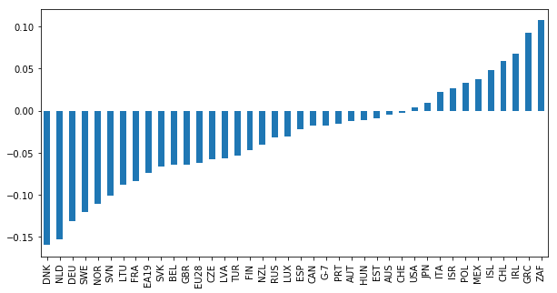

```python
country_effects.sort_values().plot(kind='bar', color='C0', figsize=(10,5))

plt.show()
```

```python
country_effects.sort_values()
```

```
DNK    -0.160212
NLD    -0.153819
DEU    -0.132315
SWE    -0.120910
NOR    -0.111396
SVN    -0.101147
LTU    -0.088568
FRA    -0.084000
EA19   -0.074231
SVK    -0.066415
BEL    -0.064644
GBR    -0.064614
EU28   -0.062364
CZE    -0.057927
LVA    -0.056449
TUR    -0.053514
FIN    -0.046676
NZL    -0.041090
RUS    -0.031850
LUX    -0.030383
ESP    -0.021911
CAN    -0.017759
G-7    -0.017594
PRT    -0.015646
AUT    -0.012938
HUN    -0.011860
EST    -0.008977
AUS    -0.004305
CHE    -0.002562
USA     0.004303
JPN     0.008918
ITA     0.022342
ISR     0.026518
POL     0.033435
MEX     0.037299
ISL     0.048435
CHL     0.059259
IRL     0.068232
GRC     0.092450
ZAF     0.107887
dtype: float64
```